# State space SAM

Alice Carter

10/27/2021

### Building a state space stochastic antecedent model

Questions: To what extent does ecosystem respiration in rivers retain memory of previous fluxes of primary productivity? In what types of rivers, or under what conditions do we observe more ecological memory? Over what time scale (days, weeks) does this memory occur?

Hypotheses: Rivers with higher fluxes of primary productivity will derive a greater portion of their respiration from autochthonous production, resulting in a possibility for ecological memory of productivity in respiration fluxes. Community dynamics will determine the likelihood of a time lag with phytoplankton dominated communities deriving most of their respiration from that days productivity and benthic, macrophyte dominated comunities demonstrating time lags in the response of ER to GPP.

## Snake River Metabolism

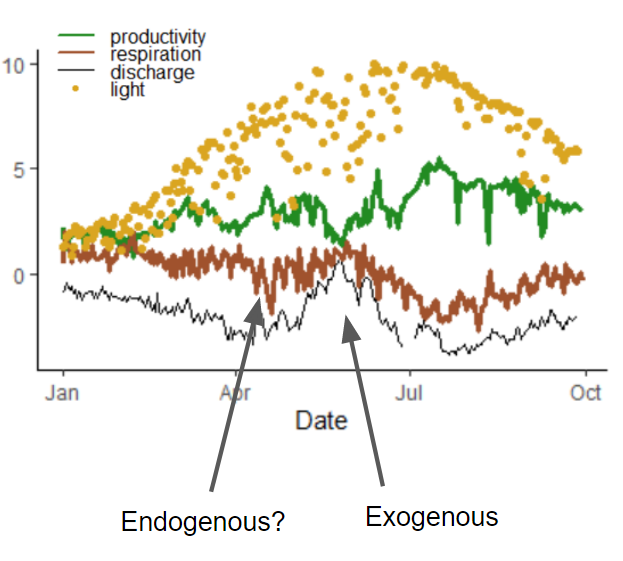

## Model

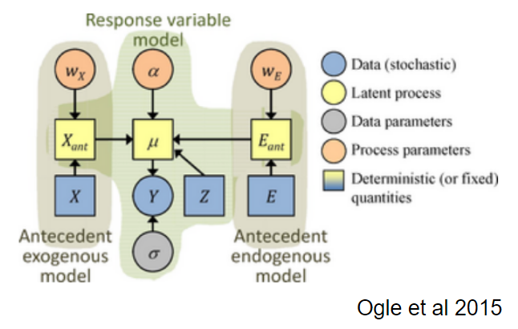

Model the underlying state of respiration ($R$) as a linear function of GPP on prior days:

$R_t = a_0 + a_1 P^{ant}_t + \varepsilon_t$

where $P^{ant}_t$ is a function of the previous j days of productivity (j = 0 is the current day)

and process error is incorporated as:

$\varepsilon_t \sim N (0, \sigma_{proc})$

Priors are minimally informative, but a special prior on $w$, which is a simplex

$w \sim dirichlet(1,1,...1)$

### Initial Results

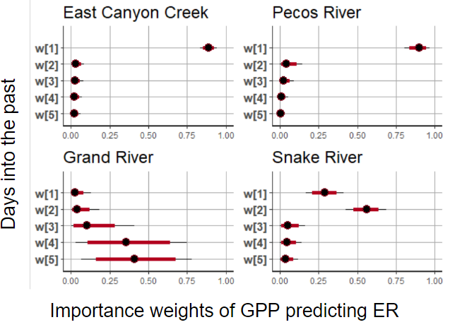

### Hypothesis:

Rivers like East Canyon Creek and Pecos are phytoplankton dominated and most respiration is autotrophic, so we do not observe a lag. By contrast, the Grand River and the Snake River may have more complex primary producer and heterotroph communities and primary productivity from several days ago impacts rates of respiration.

### Stan Code

```r
sink("src/SAM/stan/SAM.stan")

cat("
    data {
      int <lower = 0> N;
      vector [N] P;
      vector [N] R_obs;
      int <lower = 0> nweight;
      vector [nweight] alpha;
    }

    parameters {
      real a0;
      real <lower =0> a1;
      simplex [nweight] w;
      real <lower=0> sigma;
    }

    transformed parameters{
      vector  [N] Pant;
      Pant[1:5] = P[1:5];

      for (i in 6:N){
        vector  [nweight] Pvec;
        for(j in 1:nweight){
          Pvec[j]=w[j]*P[i-(j-1)];
        }
        Pant[i]=sum(Pvec);
      }
    }

    model {
      for (i in 6:N){
        R[i] ~ normal(a0 + a1*Pant[i], sigma); // likelihood
      }


    a0 ~ normal(0,5); //priors
    a1 ~ normal(0,1);
    w ~ dirichlet(alpha);
    sigma ~ normal(0,1) T[0,];
    }

    generated quantities{
      vector [N] R_hat;
      R_hat[1:5] = R[1:5];
      for(i in 6:N){
        R_hat[i] = normal_rng(a0 + a1 * Pant[i], sigma);
      }

    }" ,fill=TRUE)

sink()
```

### Simulated Parameter Recovery: Assign weight with 50% each on lags day 1 and 2

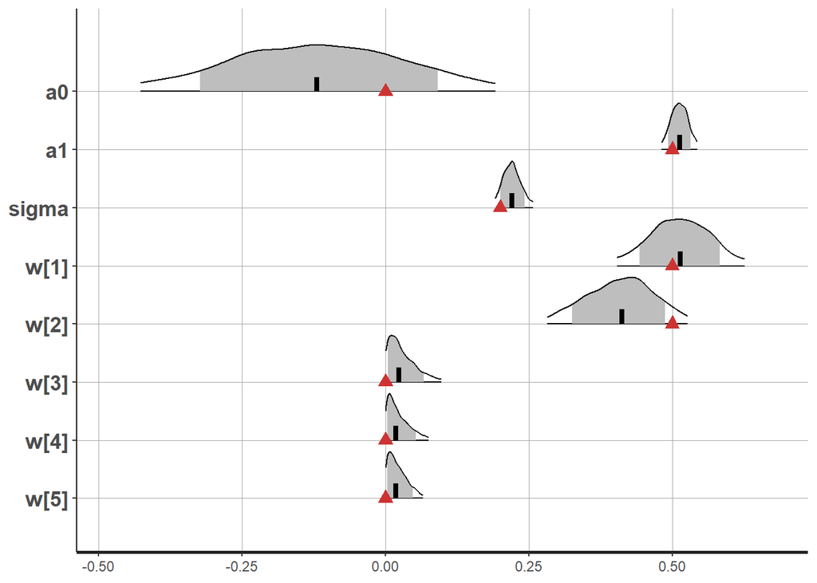

### Test model performance on real data

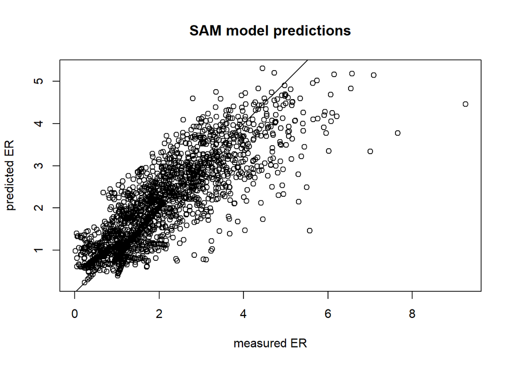

The predictions correlate reasonably well with the data, but we have not sufficiently captured the autocorrelation in respiration with this model.

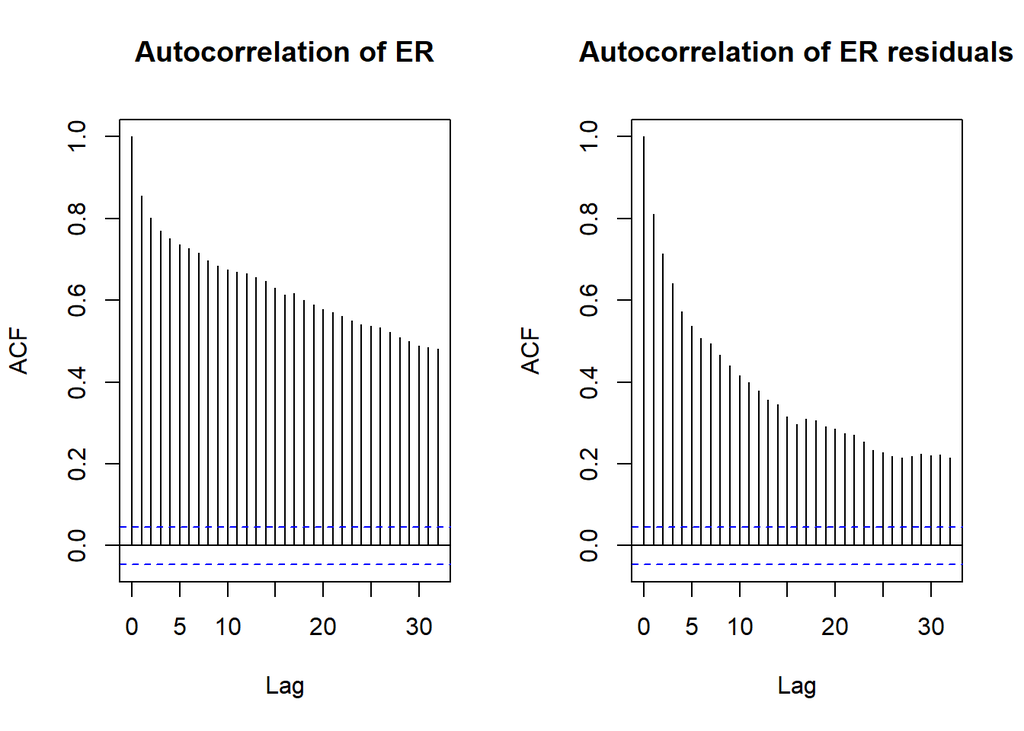

It looks like the pattern in the ER residuals might be seasonal:

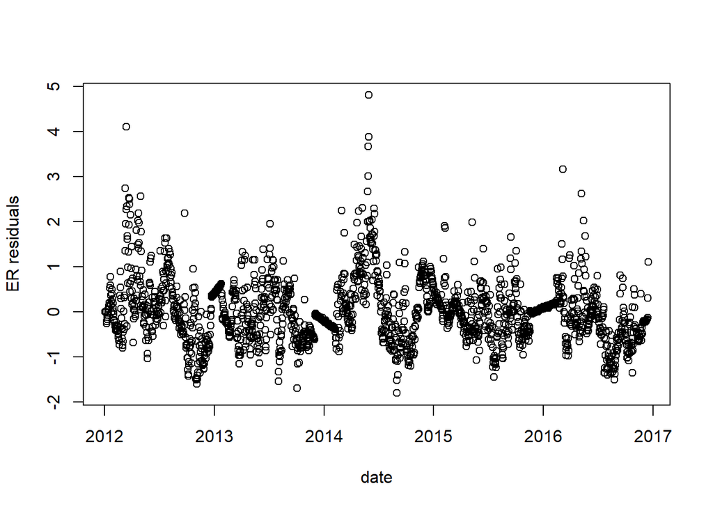

The residuals suggest the model is underestimating the impact of GPP on ER in the spring and overestimating it in the fall. This makes ecological sense and is a good argument for running this model seasonally

## Adding an autoregressive term:

Stan code for AR1 model:

```r
sink('stan/ar1_model_lognormal.stan')
cat("
  data {
    int <lower = 0> N; // Sample size
    vector[N] R_obs;
    real mu_obs;
  }

  parameters {
    real a0; // Intercept
    real <lower = 0, upper = 1> a1; //phi
    real <lower = 0> sigma_proc;
    real <lower = 0> sigma_obs;
    vector <lower = 0> [N] R;

  }

  model {
    R[1] ~ lognormal(log(R_obs[1]), 0.05);
    for(t in 2:N){
      R[t] ~ lognormal(log(a0 + a1 * R[t-1]), sigma_proc);
      R_obs[t] ~ lognormal(log(R[t]), sigma_obs);
    }

    a0 ~ normal(0,1);
    a1 ~ uniform(0,1);
    sigma_proc ~ normal(0,0.2) T[0,];
    sigma_obs ~ normal(mu_obs, mu_obs/2) T[0,];
  }

  generated quantities {

  }", fill = T)


sink()
```

Stan code for combined SAM and ar1 model

```r
sink("src/SAM/stan/SAM_ar1.stan")

cat("

data {
 int <lower = 0> N;
 vector[N] R;
 vector [N] P;
 int <lower = 0> nweight;
 vector [nweight] alpha;
}

parameters {
 real a0; // Intercept
 real < lower = 0, upper = 1> a1;
 real <lower =0> a2;
 real < lower = 0 > sigma_obs;
 real < lower = 0 > sigma_proc;
 simplex [nweight] w;
 vector [N] mu;
}

transformed parameters{
 vector  [N] Pant;
 Pant[1:5] = P[1:5];

 for (i in 6:N){
   vector  [nweight] Pvec;
   for(j in 1:nweight){
     Pvec[j]=w[j]*P[i-(j-1)];
   }
   Pant[i]=sum(Pvec);
 }
}

model {
 mu[1:5] ~ normal(R[1:5], 0.01);
 for (i in 6:N){
  mu[i] ~ normal(a0 + a1 * mu[i-1] + a2*Pant[i], sigma_proc);
  R[i] ~ normal(mu[i], sigma_obs);
 }

 a0 ~ normal(0,5); //priors
 a1 ~ uniform(0,1);
 a2 ~ normal(0,1) T[0,];
 w ~ dirichlet(alpha);
 sigma_obs ~ normal(0,1) T[0,];
 sigma_proc ~ normal(0,1) T[0,];
}

generated quantities {
  vector [N] R_hat;
  R_hat[1:5] = R[1:5];
  for(i in 6:N){
    R_hat[i] = normal_rng(a0 + a1 * R_hat[i-1] + a2*Pant[i], sigma_proc);
  }

}", fill = T)
sink()
```

### Model equations:

$R_t \sim N(a_0 + a_1 R_{t-1} + a_2 P^{ant}_t, \sigma_{proc})$

where $P_ant$ is a function of the previous j days of productivity (j = 0 is the current day)

and observation error is incorporated as:

$R_{obs,t} \sim N (R_t, \sigma_{obs})$

In the simulated data for this model, I set the parameters as follows:

$a_0 = 0$, intercept

$a_1 = 0.7$, autoregressive coefficient

$a_2 = 0.3$, antecedent model coefficient

$w <- c(0.5,0.5,0,0,0)$, weights on previous days

$\sigma_{proc} = 0.5$

$\sigma_{obs} = 0.2$

Again, I was able to recover the parameters, but with considerable uncertainty in the value of the intercept and in the weights on prior values of GPP.

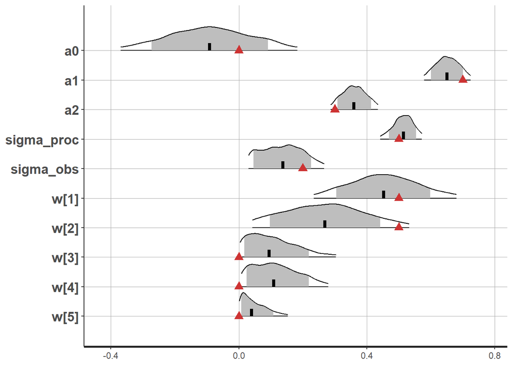

Also, the estimates for the autoregressive term, $a1$ and the antecedent term $a2$ are trading off significantly.

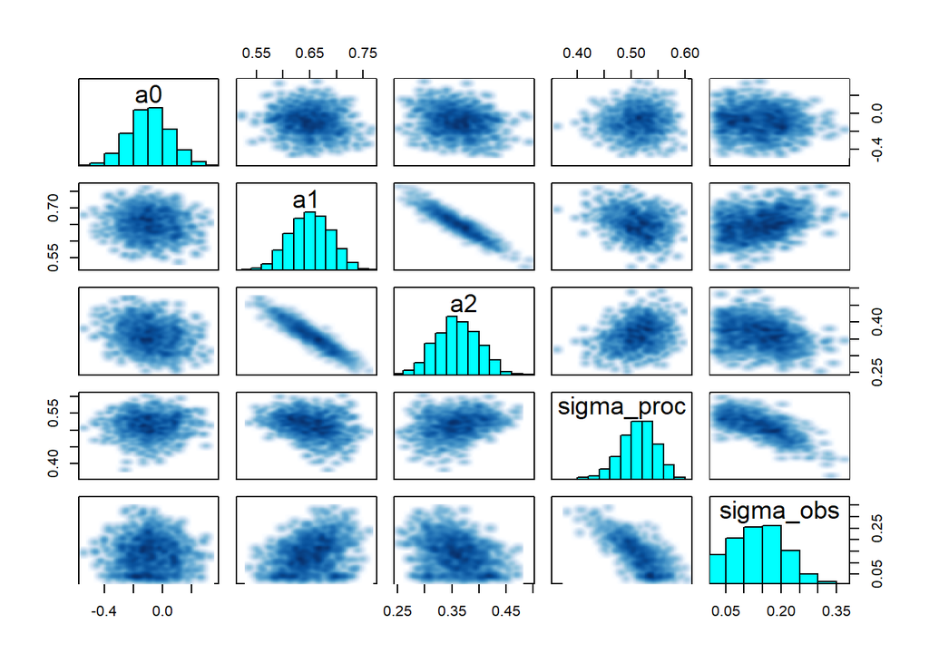

## Input:

1. How to refine combined model (improving model code, or suggestions for important covariates, etc.)
2. What are the most interesting questions to start out with ?
- time varying parameters, cross site comparisons, …